# Protocol variables

Descriptive analysis

Compounds included in document:

```
##  [1] "MEP"      "MiBP"     "MnBP"     "MBzP"     "MEHP"     "MEHHP"
##  [7] "MEOHP"    "MECPP"    "MMCHP"    "ohMiNP"   "oxoMiNP"  "cxMiNP"
## [13] "ohMINCH"  "oxoMINCH" "ohMPHP"
```

# 1 Intro

The protocol variables under study are:

- Batch
- Defreeze time
- Transport time
- Number of urine samples in the urine pool

Number of urine samples by trimester

| period | n |
| --- | --- |
| T1 | 477 |
| T3 | 456 |

# 2 Batch

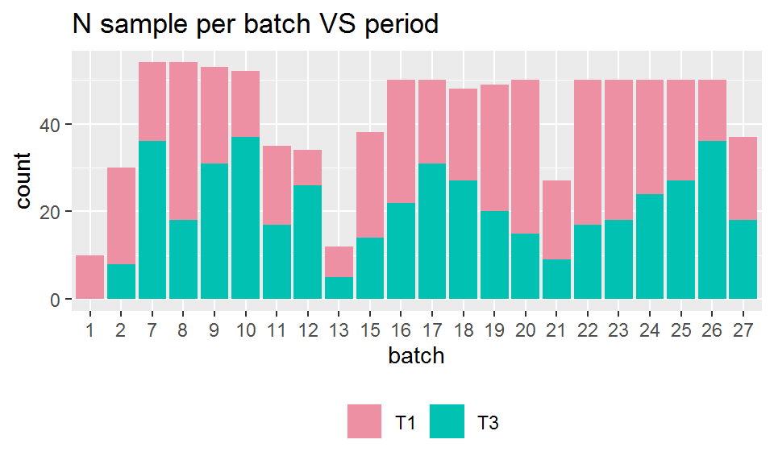

- Batch 7 used as reference

# 3 Defreeze time, transport time and N sample

Impossible values such as negative or null times were set to `NA`:

- N negative or null defreeze times: 10
- N negative or null transport times: 9

Transport time was log transformed due to strong skewness.

And defreeze times were used as tertiles because of the outliers that were pulling the trends.

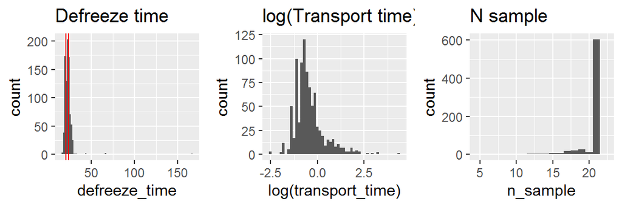

# 4 Censorship

Data below LOD will be imputed by *LOD/sqrt(2)*, OK when few number of samples < LOD.

| compound | n_below_lod |
| --- | --- |
| cxMiNP | 0 |
| MBzP | 0 |
| MECPP | 0 |
| MEHHP | 0 |
| MEHP | 1 |
| MEOHP | 0 |
| MEP | 0 |
| MiBP | 0 |
| MMCHP | 5 |
| MnBP | 0 |
| ohMINCH | 0 |
| ohMiNP | 0 |
| ohMPHP | 0 |
| oxoMINCH | 2 |
| oxoMiNP | 0 |

# 5 Distributions

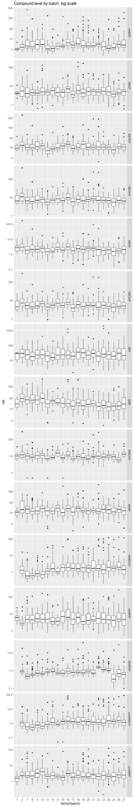

# 6 Univariate analysis

## 6.1 DAG

DAG for variables in link with protocol variables.

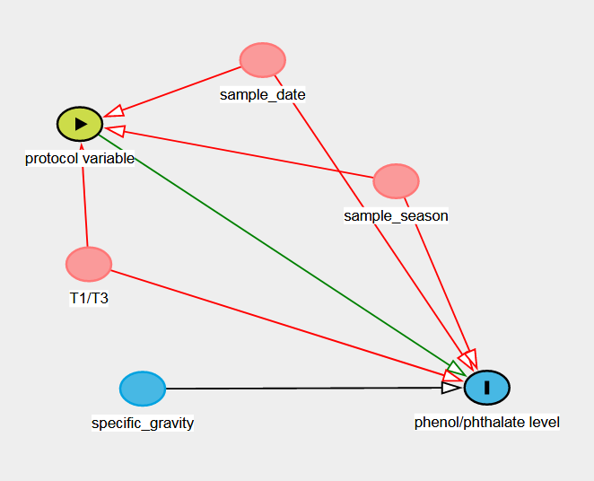

For each of the 4 protocol variables a linear regression is fit adjusted on known confounding factors (cf. DAG + phenols paper):

- `specific_gravity`
- `sample_date` (linear time trend)
- `sample_season` (categorical)
- `period` (T1 vs T3)

## 6.2 Model outputs

p-values in the adjusted regressions

| compound | p_batch | p_def_time | p_trans_time | p_n_sample |
| --- | --- | --- | --- | --- |
| cxMiNP | 0 | 0.89 | 0.893 | 0.236 |
| MBzP | 0.233 | 0.089 | 0.783 | 0.743 |
| MECPP | 0 | 0.438 | 0.23 | 0.069 |
| MEHHP | 0.184 | 0.86 | 0.556 | 0.198 |
| MEHP | 0.033 | 0.556 | 0.823 | 0.291 |
| MEOHP | 0.006 | 0.928 | 0.362 | 0.089 |
| MEP | 0.088 | 0.899 | 0.483 | 0.512 |
| MiBP | 0 | 0.364 | 0.253 | 0.033 |
| MMCHP | 0 | 0.193 | 0.82 | 0.503 |
| MnBP | 0.013 | 0.492 | 0.956 | 0.681 |
| ohMINCH | 0 | 0.742 | 0.4 | 0.416 |
| ohMiNP | 0.146 | 0.156 | 0.929 | 0.498 |
| ohMPHP | 0 | 0.045 | 0.875 | 0.307 |
| oxoMINCH | 0 | 0.799 | 0.361 | 0.498 |
| oxoMiNP | 0.001 | 0.683 | 1 | 0.067 |